# Analysis for Cornish et al. (submitted)

“In order to determine whether string sets are being acquired more faithfully over time, we calculated error between generations in terms of the normalized edit distance”

```r
# setwd('/Users/rickdale/Dropbox/projects/studies/rickmorten/cornishetal/paper/newstuff/newdata/')
set.seed(2) # stable randomization seed for statistics in paper; patterns hold in all seeds explored
library(lme4)
```

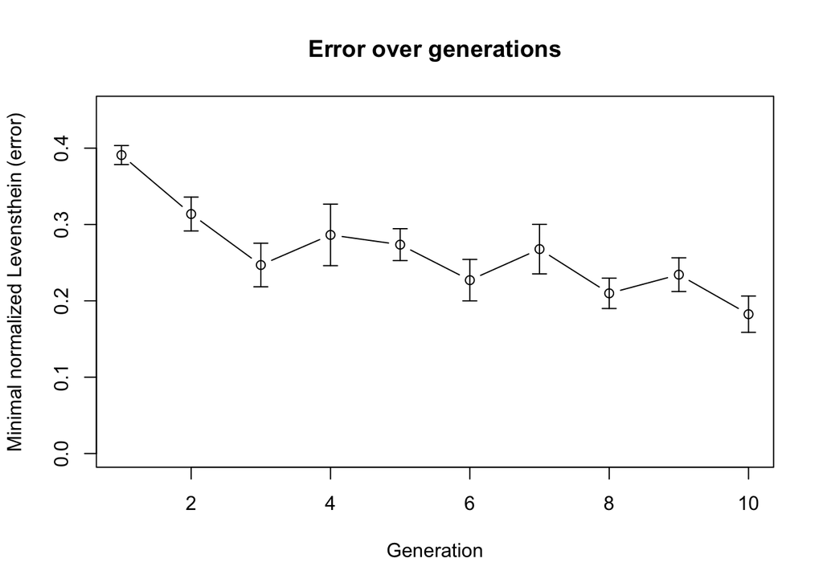

```r
mindists = matrix(nrow=8,ncol=10)
numzeros = matrix(nrow=8,ncol=10)
avglen = matrix(nrow=8,ncol=10)
for (chain in 1:8) {
  # load this chain file
  strs = read.table(paste('data/chain',chain,'.chain',sep=''),sep='\t')
  for (generation in 2:11) {
    dists = adist(strs[,generation-1],strs[,generation])
    lens = matrix(nchar(as.character(strs[,generation-1])),ncol=15,nrow=15)
    dists = dists/lens # normalized by length
    mindists[chain,generation-1] = mean(apply(dists,1,min)) # simply takes first minimum
    numzeros[chain,generation-1] = sum(apply(dists,1,function(x) {x==0})) # count # of totally correct ones
    avglen[chain,generation-1] = mean(nchar(as.character(strs[,generation])))
  }
}
shft = .1
ms = colMeans(mindists)
sds = apply(mindists,2,sd)
plot(ms,type='b',xlab='Generation',
     ylab='Minimal normalized Levensthein (error)',
     ylim=c(0,.45),main='Error over generations')
segments(1:10,ms+sds/sqrt(10),1:10,ms-sds/sqrt(10))
segments(1:10-shft,ms+sds/sqrt(10),1:10+shft,ms+sds/sqrt(10))
segments(1:10-shft,ms-sds/sqrt(10),1:10+shft,ms-sds/sqrt(10))
```

```r
regdata = cbind(which(mindists>-1,arr.ind=T),mindists[which(mindists>-1,arr.ind=T)])
lmo = lmer(regdata[,3]~regdata[,2]+(1+regdata[,2]|regdata[,1]))
coefs = data.frame(summary(lmo)$coefficients)
coefs$p = 2*(1-pnorm(abs(coefs$t.value)));coefs
```

```
##                 Estimate  Std..Error   t.value            p
## (Intercept)   0.35399074 0.018938164 18.691925 0.000000e+00
## regdata[, 2] -0.01648569 0.003510404 -4.696237 2.649981e-06
```

```r
t.test(mindists[,1]-mindists[,10])
```

```
##
##  One Sample t-test
##
## data:  mindists[, 1] - mindists[, 10]
## t = 5.8193, df = 7, p-value = 0.0006506
## alternative hypothesis: true mean is not equal to 0
## 95 percent confidence interval:
##  0.1237614 0.2931830
## sample estimates:
## mean of x
## 0.2084722
```

```r
mean(mindists[,1]);sd(mindists[,1])
```

```
## [1] 0.3909722
```

```
## [1] 0.03937536
```

```r
mean(mindists[,10]);sd(mindists[,10])
```

```
## [1] 0.1825
```

```
## [1] 0.07519698
```

“The boost in overall accuracy translates into a significant increase in the number of correctly recalled items”

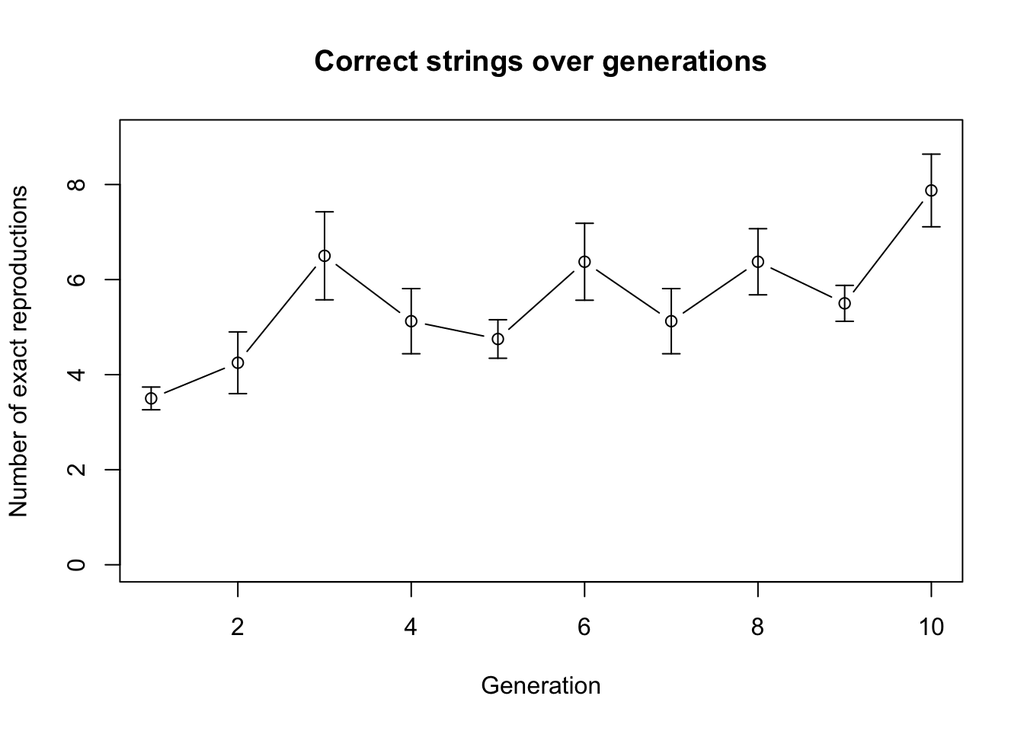

```r
ms = colMeans(numzeros)
sds = apply(numzeros,2,sd)
plot(ms,type='b',xlab='Generation',ylab='Number of exact reproductions',
     ylim=c(0,9),main='Correct strings over generations')
segments(1:10,ms+sds/sqrt(10),1:10,ms-sds/sqrt(10))
segments(1:10-shft,ms+sds/sqrt(10),1:10+shft,ms+sds/sqrt(10))
segments(1:10-shft,ms-sds/sqrt(10),1:10+shft,ms-sds/sqrt(10))
```

```r
regdata = cbind(which(numzeros>-1,arr.ind=T),numzeros[which(numzeros>-1,arr.ind=T)])
lmo = lmer(regdata[,3]~regdata[,2]+(1+regdata[,2]|regdata[,1]))
coefs = data.frame(summary(lmo)$coefficients)
coefs$p = 2*(1-pnorm(abs(coefs$t.value)));coefs
```

```
##               Estimate Std..Error  t.value            p
## (Intercept)  3.9000000  0.4992578 7.811596 5.551115e-15
## regdata[, 2] 0.2977273  0.0817507 3.641892 2.706411e-04
```

```r
t.test(numzeros[,1]-numzeros[,10])
```

```
##
##  One Sample t-test
##
## data:  numzeros[, 1] - numzeros[, 10]
## t = -4.7317, df = 7, p-value = 0.002128
## alternative hypothesis: true mean is not equal to 0
## 95 percent confidence interval:
##  -6.561364 -2.188636
## sample estimates:
## mean of x
##    -4.375
```

```r
mean(numzeros[,1]);sd(numzeros[,1])
```

```
## [1] 3.5
```

```
## [1] 0.7559289
```

```r
mean(numzeros[,10]);sd(numzeros[,10])
```

```
## [1] 7.875
```

```
## [1] 2.416461
```

“Importantly, the improved learnability did not come at the cost of a collapse of the string sets into very short sequences”

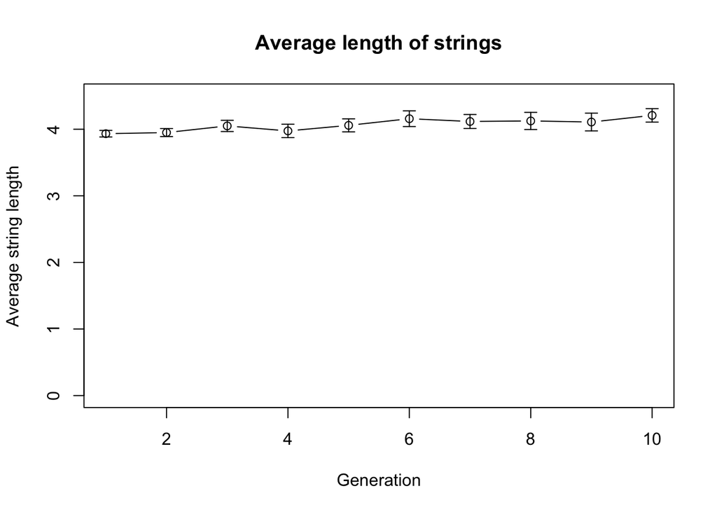

```r
ms = colMeans(avglen)
sds = apply(avglen,2,sd)
plot(ms,type='b',xlab='Generation',ylab='Average string length',
     ylim=c(0,4.5),main='Average length of strings')
segments(1:10,ms+sds/sqrt(10),1:10,ms-sds/sqrt(10))
segments(1:10-shft,ms+sds/sqrt(10),1:10+shft,ms+sds/sqrt(10))
segments(1:10-shft,ms-sds/sqrt(10),1:10+shft,ms-sds/sqrt(10))
```

```r
regdata = cbind(which(avglen>-1,arr.ind=T),avglen[which(avglen>-1,arr.ind=T)])
lmer(regdata[,3]~regdata[,2]+(1+regdata[,2]|regdata[,1]))
```

```
## Linear mixed model fit by REML ['lmerMod']
## Formula: regdata[, 3] ~ regdata[, 2] + (1 + regdata[, 2] | regdata[, 1])
## REML criterion at convergence: -28.1828
## Random effects:
##  Groups       Name         Std.Dev. Corr
##  regdata[, 1] (Intercept)  0.13241
##               regdata[, 2] 0.04044  -0.05
##  Residual                  0.15534
## Number of obs: 80, groups:  regdata[, 1], 8
## Fixed Effects:
##  (Intercept)  regdata[, 2]
##      3.91889       0.02717
```

```r
lmo = lmer(regdata[,3]~regdata[,2]+(1+regdata[,2]|regdata[,1]))
coefs = data.frame(summary(lmo)$coefficients)
coefs$p = 2*(1-pnorm(abs(coefs$t.value)));coefs
```

```
##                Estimate Std..Error  t.value          p
## (Intercept)  3.91888889 0.05999265 65.32282 0.00000000
## regdata[, 2] 0.02717172 0.01552305  1.75041 0.08004752
```

```r
t.test(avglen[,1]-avglen[,10])
```

```
##
##  One Sample t-test
##
## data:  avglen[, 1] - avglen[, 10]
## t = -2.2703, df = 7, p-value = 0.05745
## alternative hypothesis: true mean is not equal to 0
## 95 percent confidence interval:
##  -0.56142832  0.01142832
## sample estimates:
## mean of x
##    -0.275
```

```r
mean(avglen[,1]);sd(avglen[,1])
```

```
## [1] 3.933333
```

```
## [1] 0.1553286
```

```r
mean(avglen[,10]);sd(avglen[,10])
```

```
## [1] 4.208333
```

```
## [1] 0.319598
```

“Figure 2 indicates that the amount of reuse of chunks (structure) does increase over time”

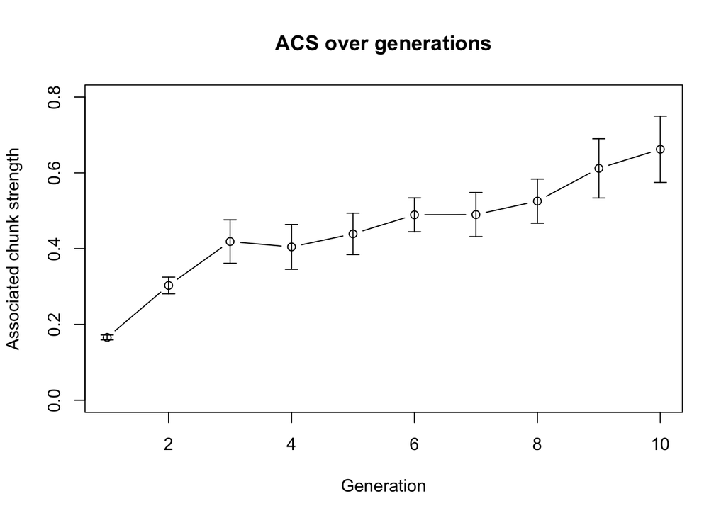

```r
bitrifound = function(s1) {
  bigs = unlist(strsplit(s1,""))
  bigs = unique(cbind(bigs[1:(length(bigs)-1)],bigs[2:length(bigs)]))
  nbigs = 0;totbigs = data.frame()
  for (s2 in strings) { # loop through all strings, comparing bigrams... determine # of shared bigrams across all
    s2 = unlist(strsplit(s2,""))
    s2 = unique(cbind(s2[1:(length(s2)-1)],s2[2:length(s2)]))
    all = rbind(bigs,s2)
    nbigs = nbigs + dim(all)[1] - dim(unique(all))[1] # total bigrams shared
    totbigs = rbind(totbigs,s2)
  }
  ntris = 0;tottris = data.frame()
  if (nchar(s1)>=3) {
    tris = unlist(strsplit(s1,""))
    tris = unique(cbind(tris[1:(length(tris)-2)],tris[2:(length(tris)-1)],tris[3:length(tris)]))
    for (s2 in strings[nchar(strings)>=3]) { # loop through only those that had trigrams
      s2 = unlist(strsplit(s2,""))
      s2 = unique(cbind(s2[1:(length(s2)-2)],s2[2:(length(s2)-1)],s2[3:length(s2)]))
      all = rbind(tris,s2)
      ntris = ntris + dim(all)[1] - dim(unique(all))[1] # total trigrams shared
      tottris = rbind(tottris,s2)
    }
  }
  return(ntris/dim(unique(tottris))[1]+nbigs/dim(unique(totbigs))[1])
  #return(ntris+nbigs)
}

ACS = matrix(nrow=8,ncol=10)
for (chain in 1:8) {
  # load this chain file
  strs = read.table(paste('data/chain',chain,'.chain',sep=''),sep='\t')
  for (generation in 2:11) {
    strings <<- as.character(strs[,generation-1])
    thisgen = as.character(strs[,generation])
    total_shared = mean(apply(data.frame(thisgen),1,bitrifound))
    ACS[chain,generation-1] = total_shared
  }
}

shft = .1
ms = colMeans(ACS)
sds = apply(ACS,2,sd)
plot(ms,type='b',xlab='Generation',
     ylab='Associated chunk strength',
     ylim=c(0,0.8),main='ACS over generations')
segments(1:10,ms+sds/sqrt(10),1:10,ms-sds/sqrt(10))
segments(1:10-shft,ms+sds/sqrt(10),1:10+shft,ms+sds/sqrt(10))
segments(1:10-shft,ms-sds/sqrt(10),1:10+shft,ms-sds/sqrt(10))
```

```r
regdata = cbind(which(ACS>-1,arr.ind=T),ACS[which(ACS>-1,arr.ind=T)])
lmo = lmer(regdata[,3]~regdata[,2]+(1+regdata[,2]|regdata[,1]))
coefs = data.frame(summary(lmo)$coefficients)
coefs$p = 2*(1-pnorm(abs(coefs$t.value)));coefs
```

```
##                Estimate Std..Error  t.value            p
## (Intercept)  0.20186912 0.03517722 5.738632 9.544408e-09
## regdata[, 2] 0.04528517 0.01055163 4.291772 1.772531e-05
```

```r
t.test(ACS[,1]-ACS[,10])
```

```
##
##  One Sample t-test
##
## data:  ACS[, 1] - ACS[, 10]
## t = -5.0045, df = 7, p-value = 0.001557
## alternative hypothesis: true mean is not equal to 0
## 95 percent confidence interval:
##  -0.7312048 -0.2619407
## sample estimates:
##  mean of x
## -0.4965727
```

```r
mean(ACS[,1]);sd(ACS[,1])
```

```
## [1] 0.1656503
```

```
## [1] 0.02054723
```

```r
mean(ACS[,10]);sd(ACS[,10])
```

```
## [1] 0.662223
```

```
## [1] 0.276845
```

[Here we plot the 2x2 Figure 1]

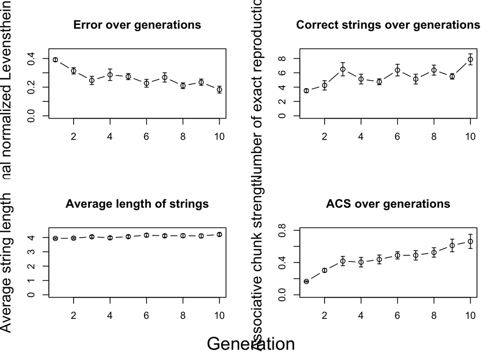

```r
# dev.new()
# pdf(file="Figure1.pdf",width=10,height=10)
par(mfrow = c(2, 2))
shft = .1
ms = colMeans(mindists)
sds = apply(mindists,2,sd)
plot(ms,type='b',xlab='',
     ylab='Minimal normalized Levensthein (error)',
     ylim=c(0,.45),main='Error over generations',cex.lab=1.5)
segments(1:10,ms+sds/sqrt(10),1:10,ms-sds/sqrt(10))
segments(1:10-shft,ms+sds/sqrt(10),1:10+shft,ms+sds/sqrt(10))
segments(1:10-shft,ms-sds/sqrt(10),1:10+shft,ms-sds/sqrt(10))
ms = colMeans(numzeros)
sds = apply(numzeros,2,sd)
plot(ms,type='b',xlab='',ylab='Number of exact reproductions',
     ylim=c(0,9),main='Correct strings over generations',cex.lab=1.5)
segments(1:10,ms+sds/sqrt(10),1:10,ms-sds/sqrt(10))
segments(1:10-shft,ms+sds/sqrt(10),1:10+shft,ms+sds/sqrt(10))
segments(1:10-shft,ms-sds/sqrt(10),1:10+shft,ms-sds/sqrt(10))
ms = colMeans(avglen)
sds = apply(avglen,2,sd)
plot(ms,type='b',xlab='',ylab='Average string length',
     ylim=c(0,4.5),main='Average length of strings',cex.lab=1.5)
segments(1:10,ms+sds/sqrt(10),1:10,ms-sds/sqrt(10))
segments(1:10-shft,ms+sds/sqrt(10),1:10+shft,ms+sds/sqrt(10))
segments(1:10-shft,ms-sds/sqrt(10),1:10+shft,ms-sds/sqrt(10))
ms = colMeans(ACS)
sds = apply(ACS,2,sd)
plot(ms,type='b',xlab='',
     ylab='Associative chunk strength',
     ylim=c(0,0.8),main='ACS over generations',cex.lab=1.5)
segments(1:10,ms+sds/sqrt(10),1:10,ms-sds/sqrt(10))
segments(1:10-shft,ms+sds/sqrt(10),1:10+shft,ms+sds/sqrt(10))
segments(1:10-shft,ms-sds/sqrt(10),1:10+shft,ms-sds/sqrt(10))
mtext("Generation", side=1, outer=TRUE, line=-1.5, cex=1.5)
```

```r
# dev.off()
```

“Figure 2: Generations 0 (left) and 10 (right) of chain 8. These network diagrams link strings which share at least one bigram sequence”

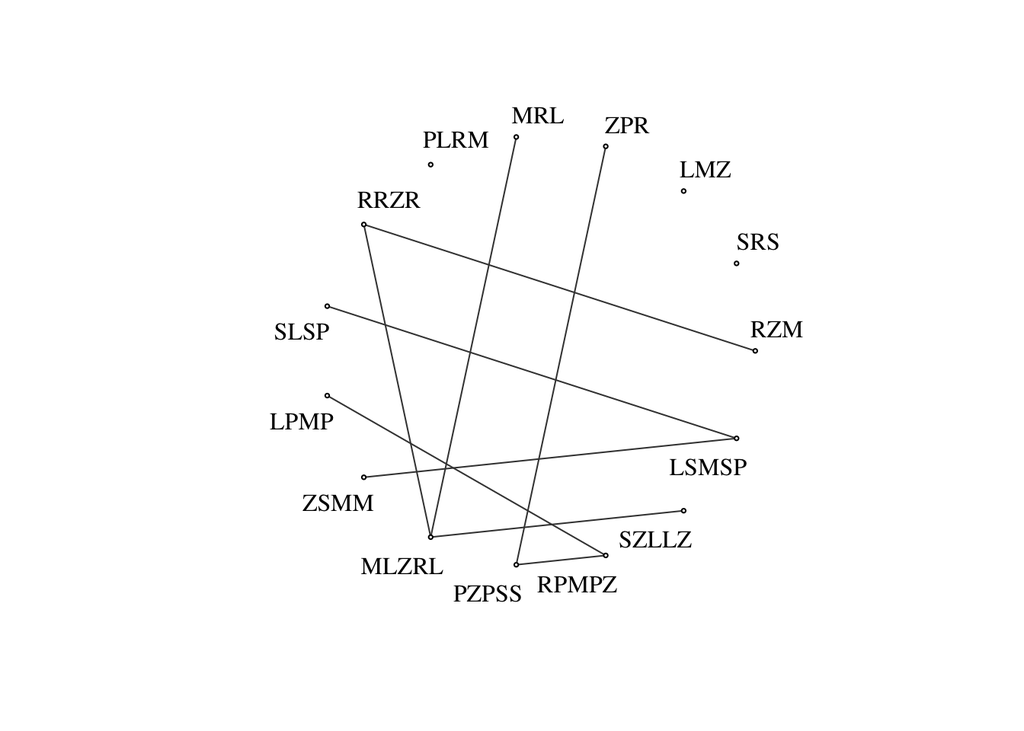

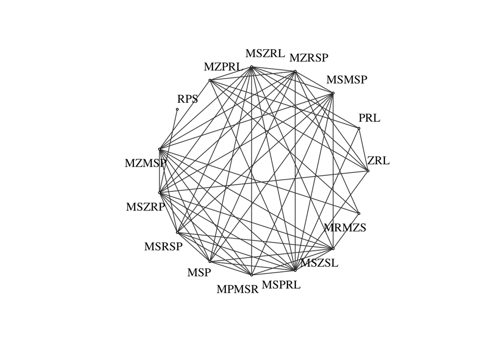

```r
library(igraph)
bigramfound = function(s1,s2) {
  s1 = unlist(strsplit(s1,""))
  s2 = unlist(strsplit(s2,""))
  s1 = unique(cbind(s1[1:(length(s1)-1)],s1[2:length(s1)]))
  s2 = unique(cbind(s2[1:(length(s2)-1)],s2[2:length(s2)]))
  all = rbind(s1,s2)
  if (dim(all)[1]>dim(unique(all))[1]) {
    bigramfound = 1
  } else {
    bigramfound = 0
  }
  return(bigramfound)
}

buildconxs = function(ix) {
    A = as.character(strings[ix[1]])
    B = as.character(strings[ix[2]])
    if (ix[1]>ix[2]) { return(bigramfound(A,B)) }
    else { return(0) }
}

for (chain in 8) {
  # load this chain file
  strs = read.table(paste('data/chain',chain,'.chain',sep=''),sep='\t')
  for (generation in c(1,11)) {
    nodes = as.character(strs[,generation])
    cmb = expand.grid(i=1:15, j=1:15)
    strings <<- nodes
    conxs = matrix(apply(cmb,1,buildconxs),15,15)
    edges = which(conxs==1,arr.ind=T)
    edges = data.frame(from=nodes[edges[,1]],to=nodes[edges[,2]])
    network=graph.data.frame(edges,directed=F,vertices=as.character(nodes))
    plot(network,layout=layout.circle,vertex.size=0,
         vertex.color=rgb(1,1,1),vertex.shape="circle",
         edge.color=rgb(0.25,0.25,0.25),
         vertex.label=as.character(nodes),
         vertex.label.color=rgb(0,0,0),vertex.label.dist=c(1:7*0+1,1:8*0-1))
  }
}
```

[Building Figure 2]

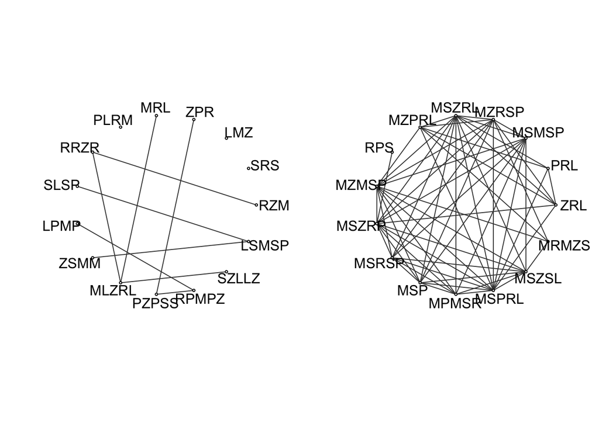

```r
# cTo = c('S','R','Z','M','L','P') # see notes about translation in "prior_code"
# cFrom = c('c','b','a','d','e','f')
# dev.new()
# pdf(file="Figure2.pdf",width=10,height=10)
par(mfrow=c(1,2))
for (chain in 8) {
  # load this chain file
  strs = read.table(paste('data/chain',chain,'.chain',sep=''),sep='\t')
  for (generation in c(1,11)) {
    nodes = as.character(strs[,generation])
    #for (charNum in 1:6) { nodes = gsub(cFrom[charNum],cTo[charNum],nodes) }
    cmb = expand.grid(i=1:15, j=1:15)
    strings <<- nodes
    conxs = matrix(apply(cmb,1,buildconxs),15,15)
    edges = which(conxs==1,arr.ind=T)
    edges = data.frame(from=nodes[edges[,1]],to=nodes[edges[,2]])
    network=graph.data.frame(edges,directed=F,vertices=as.character(nodes))
    plot(network,layout=layout.circle,vertex.size=0,vertex.label='',
         vertex.color=rgb(1,1,1),vertex.shape="circle",
         edge.color=rgb(0.25,0.25,0.25),
         vertex.label.color=rgb(0,0,0),vertex.label.dist=0*cos(seq(from=0,to=2*pi,length.out=15)))
    text(x=layout.circle(network)[,1]*1.2,y=layout.circle(network)[,2]*1.1,labels=nodes)
  }
}
```

```r
# dev.off()
```

“For each set of networks, both experimental and natural-language (and their baselines), we extracted (1) string length, and (2) the proportion of other elements to which a given string is connected. The relationship between these variables is shown as blue and red lines in Figure 4”

```r
buildconxs_full = function(ix) {
    A = as.character(strings[ix[1]])
    B = as.character(strings[ix[2]])
    if (ix[1]!=ix[2]) { return(bigramfound(A,B)) }
    else { return(0) }
}

shuffle_nodes_internally = function(node) {
  node = unlist(strsplit(as.character(node),""))
  node = paste(node[sample(length(node))],collapse="")
  return(node)
}

gens=c();props=c();lens=c();chains=c();shuff=c()
for (chain in 1:8) {
  # load this chain file
  strs = read.table(paste('data/chain',chain,'.chain',sep=''),sep='\t')
  for (generation in c(1:11)) {
    nodes = as.character(strs[,generation])
    cmb = expand.grid(i=1:15, j=1:15)
    strings <<- nodes
    conxs = matrix(apply(cmb,1,buildconxs_full),15,15) # include some connection matrix
    lens = c(lens,nchar(as.character(nodes))) # length of the strings in this generation
    props = c(props,colMeans(conxs)) # proportion to other nodes connected
    gens = c(gens,1:15*0+generation)
    chains = c(chains,1:15*0+chain)
    shuff = c(shuff,1:15*0+0)
    # time to do the shuffled versions
    nodes = apply(data.frame(nodes),1,shuffle_nodes_internally)
    cmb = expand.grid(i=1:15, j=1:15)
    strings <<- nodes
    conxs = matrix(apply(cmb,1,buildconxs_full),15,15) # include some connection matrix
    lens = c(lens,nchar(as.character(nodes))) # length of the strings in this generation
    props = c(props,colMeans(conxs)) # proportion to other nodes connected
    gens = c(gens,1:15*0+generation)
    chains = c(chains,1:15*0+chain)
    shuff = c(shuff,1:15*0+1)
  }
}

net_data = data.frame(lens,props,gens,chains,shuff)
```

```r
subd = net_data[net_data$gens==1,]
subd$lensC = subd$lens-mean(subd$lens)
summary(lm(props~shuff*lensC,data=subd))
```

```
##
## Call:
## lm(formula = props ~ shuff * lensC, data = subd)
##
## Residuals:
##       Min        1Q    Median        3Q       Max
## -0.176667 -0.047778 -0.008611  0.054167  0.254167
##
## Coefficients:
##              Estimate Std. Error t value Pr(>|t|)
## (Intercept)  0.114444   0.006986  16.383  < 2e-16 ***
## shuff        0.062222   0.009879   6.298 1.46e-09 ***
## lensC        0.039167   0.008556   4.578 7.60e-06 ***
## shuff:lensC -0.003333   0.012099  -0.275    0.783
## ---
## Signif. codes:  0 '***' 0.001 '**' 0.01 '*' 0.05 '.' 0.1 ' ' 1
##
## Residual standard error: 0.07652 on 236 degrees of freedom
## Multiple R-squared:  0.2488, Adjusted R-squared:  0.2393
## F-statistic: 26.06 on 3 and 236 DF,  p-value: 1.353e-14
```

```r
subd = net_data[net_data$gens==9,]
subd$lensC = subd$lens-mean(subd$lens)
summary(lm(props~shuff*lensC,data=subd))
```

```
##
## Call:
## lm(formula = props ~ shuff * lensC, data = subd)
##
## Residuals:
##      Min       1Q   Median       3Q      Max
## -0.48846 -0.10477 -0.01358  0.11154  0.36406
##
## Coefficients:
##             Estimate Std. Error t value Pr(>|t|)
## (Intercept)  0.37111    0.01341  27.677  < 2e-16 ***
## shuff       -0.08556    0.01896  -4.512 1.01e-05 ***
## lensC        0.13411    0.01419   9.450  < 2e-16 ***
## shuff:lensC -0.03843    0.02007  -1.915   0.0567 .
## ---
## Signif. codes:  0 '***' 0.001 '**' 0.01 '*' 0.05 '.' 0.1 ' ' 1
##
## Residual standard error: 0.1469 on 236 degrees of freedom
## Multiple R-squared:  0.3966, Adjusted R-squared:  0.3889
## F-statistic: 51.71 on 3 and 236 DF,  p-value: < 2.2e-16
```

```r
subd = net_data[net_data$gens==10,]
subd$lensC = subd$lens-mean(subd$lens)
summary(lm(props~shuff*lensC,data=subd))
```

```
##
## Call:
## lm(formula = props ~ shuff * lensC, data = subd)
##
## Residuals:
##      Min       1Q   Median       3Q      Max
## -0.38961 -0.10784 -0.02226  0.11664  0.44441
##
## Coefficients:
##             Estimate Std. Error t value Pr(>|t|)
## (Intercept)  0.38889    0.01472  26.415  < 2e-16 ***
## shuff       -0.11222    0.02082  -5.390 1.71e-07 ***
## lensC        0.15034    0.01513   9.935  < 2e-16 ***
## shuff:lensC -0.05817    0.02140  -2.718  0.00705 **
## ---
## Signif. codes:  0 '***' 0.001 '**' 0.01 '*' 0.05 '.' 0.1 ' ' 1
##
## Residual standard error: 0.1613 on 236 degrees of freedom
## Multiple R-squared:  0.4113, Adjusted R-squared:  0.4038
## F-statistic: 54.96 on 3 and 236 DF,  p-value: < 2.2e-16
```

```r
subd = net_data[net_data$gens==11,]
subd$lensC = subd$lens-mean(subd$lens)
summary(lm(props~shuff*lensC,data=subd))
```

```
##
## Call:
## lm(formula = props ~ shuff * lensC, data = subd)
##
## Residuals:
##      Min       1Q   Median       3Q      Max
## -0.33706 -0.09515 -0.00372  0.10485  0.44217
##
## Coefficients:
##             Estimate Std. Error t value Pr(>|t|)
## (Intercept)  0.34667    0.01268  27.336  < 2e-16 ***
## shuff       -0.06667    0.01793  -3.717 0.000252 ***
## lensC        0.15628    0.01351  11.571  < 2e-16 ***
## shuff:lensC -0.05293    0.01910  -2.771 0.006029 **
## ---
## Signif. codes:  0 '***' 0.001 '**' 0.01 '*' 0.05 '.' 0.1 ' ' 1
##
## Residual standard error: 0.1389 on 236 degrees of freedom
## Multiple R-squared:  0.4664, Adjusted R-squared:  0.4596
## F-statistic: 68.75 on 3 and 236 DF,  p-value: < 2.2e-16
```

“We did this same analysis across our generations of the experiment, shown in Figure 3.”

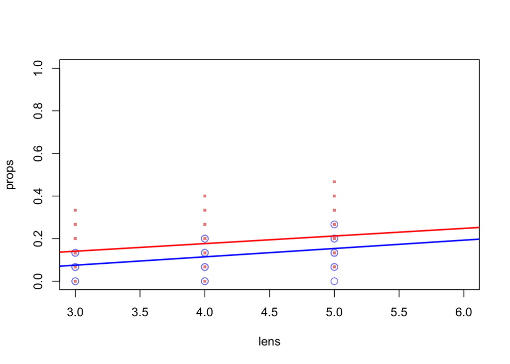

```r
subd = net_data[net_data$gens==1,]
plot(props~lens,data=subd[subd$shuff==0,],
     col=rgb(.55,.55,.9),pch=1,cex=1.25,ylim=c(0,1),xlim=c(3,6))
points(props~lens,data=subd[subd$shuff==1,],col=rgb(.9,.55,.55),pch=15,cex=.5)
lmo = lm(props~lens,data=subd[subd$shuff==0,]);
  abline(lmo,col='blue',lwd=2,xlim=c(3,6),ylim=c(0,1),xpd=F)
lmo = lm(props~lens,data=subd[subd$shuff==1,]);
  abline(lmo,col='red',lwd=2,xpd=F)
```

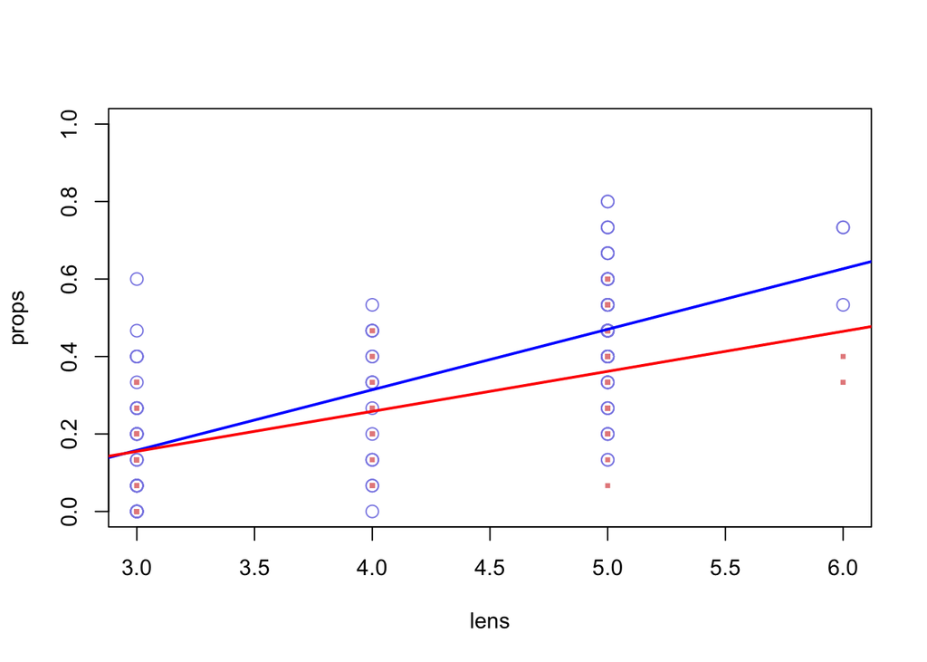

```r
subd = net_data[net_data$gens==11,]
plot(props~lens,data=subd[subd$shuff==0,],
     col=rgb(.55,.55,.9),pch=1,cex=1.25,ylim=c(0,1),xlim=c(3,6))
points(props~lens,data=subd[subd$shuff==1,],col=rgb(.9,.55,.55),pch=15,cex=.5)
lmo = lm(props~lens,data=subd[subd$shuff==0,]);
  abline(lmo,col='blue',lwd=2,xlim=c(3,6),ylim=c(0,1),xpd=F)
lmo = lm(props~lens,data=subd[subd$shuff==1,]);
  abline(lmo,col='red',lwd=2,xpd=F)
```

“For the natural-language (CHILDES) network, the original data (unshuffled) have overall greater connectivity than the shuffled data by (on average) 10%, t = 47.6, p < .0001, and the interaction in Fig. 4 (bottom right) is significant, t = 20.7, p < .0001. Importantly, these effects are still present when just focusing on strings of length 3 and 4 alone: It is not driven by the longer string sequences alone (p’s < .0001).”

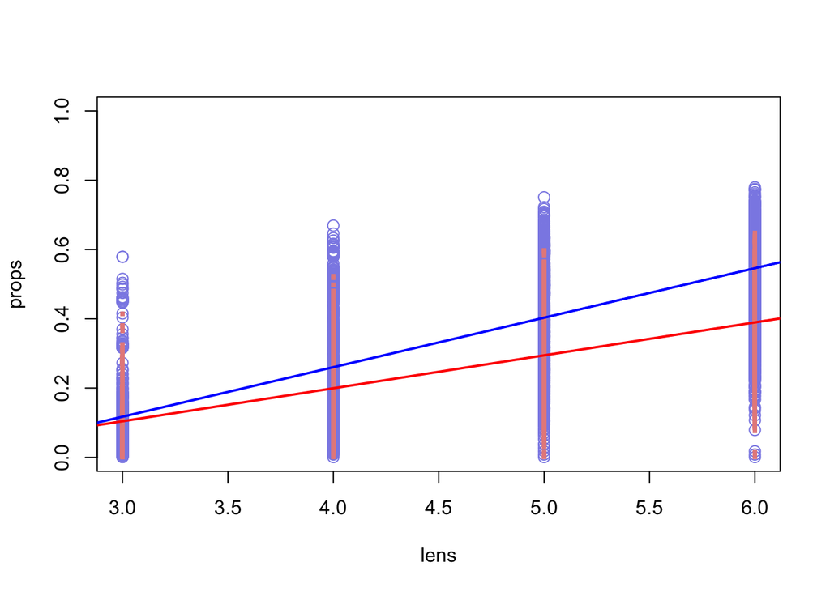

```r
pos = read.table('data/human_POS_for_R.xls')
colnames(pos) = list('shuff','lens','props')
subd = pos # just to match the code above
plot(props~lens,data=subd[subd$shuff==0,],
     col=rgb(.55,.55,.9),pch=1,cex=1.25,ylim=c(0,1),xlim=c(3,6))
points(props~lens,data=subd[subd$shuff==1,],col=rgb(.9,.55,.55),pch=15,cex=.5)
lmo = lm(props~lens,data=subd[subd$shuff==0,]);
  abline(lmo,col='blue',lwd=2,xlim=c(3,6),ylim=c(0,1),xpd=F)
lmo = lm(props~lens,data=subd[subd$shuff==1,]);
  abline(lmo,col='red',lwd=2,xpd=F)
```

```r
subd$lensC = subd$lens-mean(subd$lens)
summary(lm(props~shuff*lensC,data=subd))
```

```
##
## Call:
## lm(formula = props ~ shuff * lensC, data = subd)
##
## Residuals:
##      Min       1Q   Median       3Q      Max
## -0.54548 -0.08999 -0.00005  0.09099  0.46146
##
## Coefficients:
##              Estimate Std. Error t value Pr(>|t|)
## (Intercept)  0.399408   0.001595  250.44   <2e-16 ***
## shuff       -0.107424   0.002255  -47.63   <2e-16 ***
## lensC        0.142991   0.001638   87.30   <2e-16 ***
## shuff:lensC -0.047831   0.002316  -20.65   <2e-16 ***
## ---
## Signif. codes:  0 '***' 0.001 '**' 0.01 '*' 0.05 '.' 0.1 ' ' 1
##
## Residual standard error: 0.1262 on 12528 degrees of freedom
## Multiple R-squared:  0.5143, Adjusted R-squared:  0.5142
## F-statistic:  4421 on 3 and 12528 DF,  p-value: < 2.2e-16
```

```r
summary(lm(props~shuff*lensC,data=subd[subd$lens<=4,]))
```

```
##
## Call:
## lm(formula = props ~ shuff * lensC, data = subd[subd$lens <=
##     4, ])
##
## Residuals:
##      Min       1Q   Median       3Q      Max
## -0.25613 -0.08319 -0.03592  0.07446  0.47559
##
## Coefficients:
##              Estimate Std. Error t value Pr(>|t|)
## (Intercept)  0.406491   0.008348   48.69  < 2e-16 ***
## shuff       -0.107440   0.011806   -9.10  < 2e-16 ***
## lensC        0.153744   0.006121   25.12  < 2e-16 ***
## shuff:lensC -0.049953   0.008657   -5.77 8.54e-09 ***
## ---
## Signif. codes:  0 '***' 0.001 '**' 0.01 '*' 0.05 '.' 0.1 ' ' 1
##
## Residual standard error: 0.1231 on 3770 degrees of freedom
## Multiple R-squared:  0.2155, Adjusted R-squared:  0.2148
## F-statistic: 345.1 on 3 and 3770 DF,  p-value: < 2.2e-16
```

```r
subd1 = net_data[net_data$gens>=9,];subd1$human=0
subd1 = subset(subd1,subd1$shuff==0,c('human','lens','props'))
subd2 = pos;subd2$human=1
subd2 = subset(subd2,subd2$shuff==0,c('human','lens','props'))
compare_data = rbind(subd1,subd2)
compare_data$lensC = compare_data$lens-mean(compare_data$lens)
summary(lm(props~human*lensC,data=compare_data))
```

```
##
## Call:
## lm(formula = props ~ human * lensC, data = compare_data)
##
## Residuals:
##      Min       1Q   Median       3Q      Max
## -0.54548 -0.09899  0.00033  0.09660  0.46508
##
## Coefficients:
##              Estimate Std. Error t value Pr(>|t|)
## (Intercept)  0.482598   0.009575  50.401   <2e-16 ***
## human       -0.089596   0.009739  -9.200   <2e-16 ***
## lensC        0.145831   0.007775  18.758   <2e-16 ***
## human:lensC -0.002841   0.007986  -0.356    0.722
## ---
## Signif. codes:  0 '***' 0.001 '**' 0.01 '*' 0.05 '.' 0.1 ' ' 1
##
## Residual standard error: 0.1406 on 6622 degrees of freedom
## Multiple R-squared:  0.4957, Adjusted R-squared:  0.4955
## F-statistic:  2170 on 3 and 6622 DF,  p-value: < 2.2e-16
```

```r
subd1 = net_data[net_data$gens %in% c(2,3,4),];subd1$human=0
subd1 = subset(subd1,subd1$shuff==0,c('human','lens','props'))
subd2 = pos;subd2$human=1
subd2 = subset(subd2,subd2$shuff==0,c('human','lens','props'))
compare_data = rbind(subd1,subd2)
compare_data$lensC = compare_data$lens-mean(compare_data$lens)
summary(lm(props~human*lensC,data=compare_data))
```

```
##
## Call:
## lm(formula = props ~ human * lensC, data = compare_data)
##
## Residuals:
##      Min       1Q   Median       3Q      Max
## -0.54548 -0.09854  0.00129  0.09612  0.46146
##
## Coefficients:
##             Estimate Std. Error t value Pr(>|t|)
## (Intercept) 0.351127   0.011014  31.881  < 2e-16 ***
## human       0.040559   0.011153   3.637 0.000278 ***
## lensC       0.096947   0.008754  11.075  < 2e-16 ***
## human:lensC 0.046044   0.008937   5.152 2.65e-07 ***
## ---
## Signif. codes:  0 '***' 0.001 '**' 0.01 '*' 0.05 '.' 0.1 ' ' 1
##
## Residual standard error: 0.1389 on 6622 degrees of freedom
## Multiple R-squared:  0.5051, Adjusted R-squared:  0.5049
## F-statistic:  2253 on 3 and 6622 DF,  p-value: < 2.2e-16
```

[Building Figure 3]

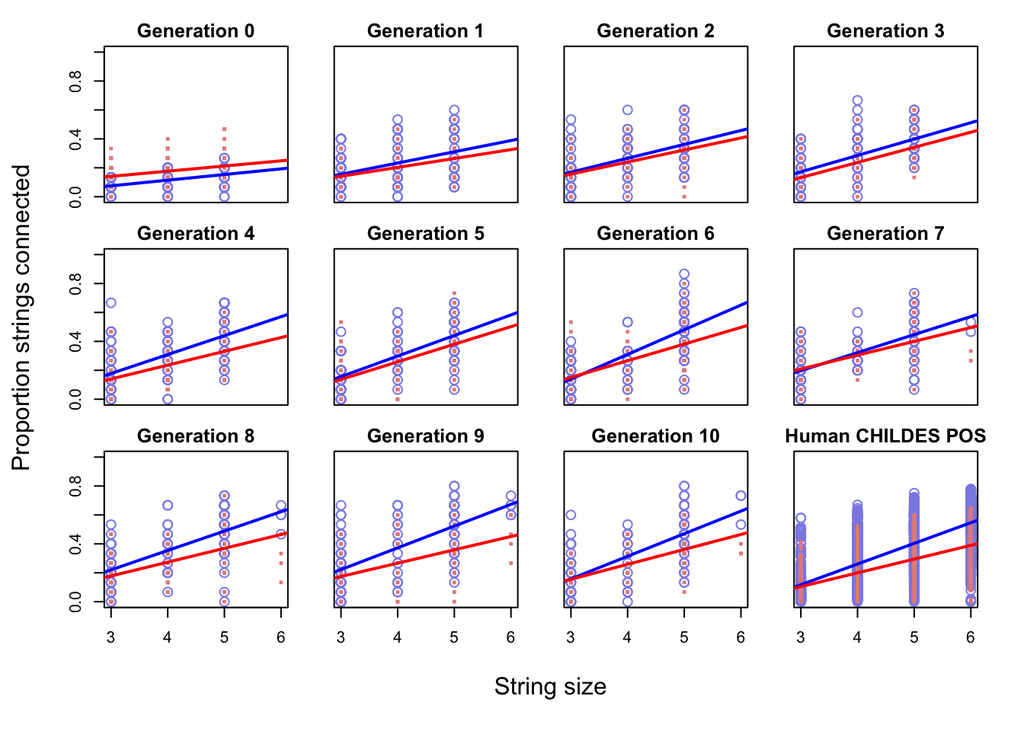

```r
# dev.new()
# pdf(file="Figure3.pdf",width=10,height=10)
par(mfrow=c(3,4),oma = c(5,4,0,0) + 0.7,mar = c(0,0,1,1) + 0.7)
for (generation in c(1:11)) {
  subd = net_data[net_data$gens==generation,]
  xset = "n";yset = "n"
  if (generation<=8) { xset="n" }
  if (generation %in% c(1,5,9)) { yset="s" }
  plot(props~lens,data=subd[subd$shuff==0,],
       col=rgb(.55,.55,.9),pch=1,cex=1.25,ylim=c(0,1),xlim=c(3,6),
       main=paste('Generation',generation-1),xaxt=xset,yaxt=yset)
  if (generation>8) { axis(1,at=c(3:6)) }
  points(props~lens,data=subd[subd$shuff==1,],col=rgb(.9,.55,.55),pch=15,cex=.5)
  lmo = lm(props~lens,data=subd[subd$shuff==0,]);
    abline(lmo,col='blue',lwd=2,xlim=c(3,6),ylim=c(0,1),xpd=F)
  lmo = lm(props~lens,data=subd[subd$shuff==1,]);
    abline(lmo,col='red',lwd=2,xpd=F)
}

title(ylab='Proportion strings connected',xlab='String size',outer=T,cex.lab=1.5)

pos = read.table('data/human_POS_for_R.xls')
colnames(pos) = list('shuff','lens','props')
subd = pos # just to match the code above
plot(props~lens,data=subd[subd$shuff==0,],
     col=rgb(.55,.55,.9),pch=1,cex=1.25,ylim=c(0,1),xlim=c(3,6),
     main="Human CHILDES POS",yaxt="n",xaxt="n")
axis(1,at=c(3:6))
points(props~lens,data=subd[subd$shuff==1,],col=rgb(.9,.55,.55),pch=15,cex=.5)
lmo = lm(props~lens,data=subd[subd$shuff==0,]);
  abline(lmo,col='blue',lwd=2,xlim=c(3,6),ylim=c(0,1),xpd=F)
lmo = lm(props~lens,data=subd[subd$shuff==1,]);
  abline(lmo,col='red',lwd=2,xpd=F)
```

```r
# dev.off()
```

Checking how many elements CHILDES POS has, hence higher connectivity for experiments vs. human data.

```r
pos_list = read.table('data/Mega-Eng-POS-CHILDES.txt',sep='\t')
items = unlist(strsplit(paste(pos_list$V2,sep=' '),' '))
unique(items)
```

```
##  [1] "co"   "n"    "pro"  "v"    "adv"  "det"  "prep" "adj"  "neg"  "on"
## [11] "conj" "qn"   "inf"  ""     "rel"  "neo"
```

```r
length(unique(items))-1
```

```
## [1] 15
```

[Fig. 4 PDF is generated in the supplementary-analysis folder.]

[Fig. 5 showing contrast in generation 1 and 10 in one chain]

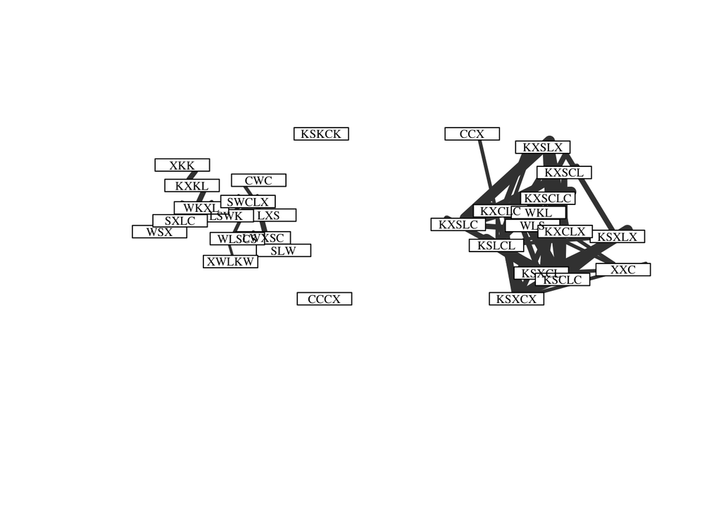

```r
# cTo = c('S','W','L','C','X','K') # for chain 3 (had to determine by hand)
# cFrom = c('c','b','a','d','e','f') # see notes about translation in prior_code
#cTo = c('c','b','a','d','e','f')
# dev.off();dev.new()
# pdf(file="Figure5.pdf",width=70,height=70)
par(mfrow=c(1,2),oma = c(5,4,0,0) + 1,mar = c(0,0,1,1) + 1)
for (chain in 3) {
  # load this chain file
  strs = read.table(paste('data/chain',chain,'.chain',sep=''),sep='\t')
  for (generation in c(1,11)) {
    nodes = as.character(strs[,generation])
    cmb = expand.grid(i=1:15, j=1:15)
    # for (charNum in 1:6) { nodes = gsub(cFrom[charNum],cTo[charNum],nodes) }
    strings <<- nodes
    conxs = matrix(apply(cmb,1,buildconxs),15,15)
    dists = adist(strings,strings)
    edges = which(conxs==1,arr.ind=T)
    weights = 10*1/dists[conxs==1]
    edges = data.frame(from=nodes[edges[,1]],to=nodes[edges[,2]])
    network=graph.data.frame(edges,directed=F,vertices=as.character(nodes))
    E(network)$weights = weights
    plot(network,layout=layout.kamada.kawai,vertex.size=66,vertex.label=nodes,
         vertex.color=rgb(1,1,1),vertex.shape="rectangle",edge.width=weights,
         edge.color=rgb(0.25,0.25,0.25),
         vertex.label.color=rgb(0,0,0),vertex.label.cex=.7)
    #text(x=layout.circle(network)[,1]*1.2,y=layout.circle(network)[,2]*1.1,labels=nodes)
  }
}
```

```r
# dev.off()
```

[All networks using Kamada-Kawai force-directed algorithm for visualization; see Fig. S1 PDF]

```r
dev.off();dev.new()
```

```r
pdf(file="FigureS1.pdf",width=70,height=70)
par(mfrow=c(8,11))
for (chain in 1:8) {
  # load this chain file
  strs = read.table(paste('data/chain',chain,'.chain',sep=''),sep='\t')
  for (generation in c(1:11)) {
    nodes = as.character(strs[,generation])
    cmb = expand.grid(i=1:15, j=1:15)
    strings <<- nodes
    conxs = matrix(apply(cmb,1,buildconxs),15,15)
    dists = adist(strings,strings)
    edges = which(conxs==1,arr.ind=T)
    weights = 10*1/dists[conxs==1]
    edges = data.frame(from=nodes[edges[,1]],to=nodes[edges[,2]])
    network=graph.data.frame(edges,directed=F,vertices=as.character(nodes))
    E(network)$weights = weights
    plot(network,layout=layout.kamada.kawai,vertex.size=50,vertex.label=nodes,
         vertex.color=rgb(1,1,1),vertex.shape="rectangle",edge.width=weights,
         edge.color=rgb(0.25,0.25,0.25),
         vertex.label.color=rgb(0,0,0))
    #text(x=layout.circle(network)[,1]*1.2,y=layout.circle(network)[,2]*1.1,labels=nodes)
  }
}
dev.off()
```

[All networks for demonstration; using bigrams; see FigureS2.pdf]

```r
dev.off();dev.new()
```

```r
pdf(file="FigureS2.pdf",width=70,height=70)
par(mfrow=c(8,11))
for (chain in 1:8) {
  # load this chain file
  strs = read.table(paste('data/chain',chain,'.chain',sep=''),sep='\t')
  for (generation in c(1:11)) {
    nodes = as.character(strs[,generation])
    cmb = expand.grid(i=1:15, j=1:15)
    strings <<- nodes
    conxs = matrix(apply(cmb,1,buildconxs),15,15)
    edges = which(conxs==1,arr.ind=T)
    edges = data.frame(from=nodes[edges[,1]],to=nodes[edges[,2]])
    network=graph.data.frame(edges,directed=F,vertices=as.character(nodes))
    plot(network,layout=layout.circle,vertex.size=0,vertex.label='',
         vertex.color=rgb(1,1,1),vertex.shape="circle",
         edge.color=rgb(0.25,0.25,0.25),
         vertex.label.color=rgb(0,0,0),vertex.label.dist=0*cos(seq(from=0,to=2*pi,length.out=15)))
    text(x=layout.circle(network)[,1]*1.2,y=layout.circle(network)[,2]*1.1,labels=nodes)
  }
}
dev.off()
```